# Does my model look f(l)at in this parameter?

Irshaad Vawda | 22 March 2020

(When viewing from mobile, swipe left to see the "footnotes" in the right-hand margin)

# Whose COVID-19 model is correct?

Newton apparently [discovered calculus](https://www.washingtonpost.com/history/2020/03/12/during-pandemic-isaac-newton-had-work-home-too-he-used-time-wisely/) while in isolation during the plague, so similarly this is my attempt at profundity.

After Cambridge sent all their students home, so Universities closing for epidemics is as old as…well calculus (at least)

Firstly, I’ve never seen anything like COVID-19 in my life. It’s completely up-ended my life. I’m currently self-isolating after my recent travels, and I’m frankly pretty scared of the virus.

During this time, I’ve been glued to my Twitter feed, which has been completely dominated by COVID-19. It’s been an apocalypse on Twitter, and in the view of some of my family members, this is the reason for my fear and “over-reaction”. “This thing is exaggerated” someone close to me said to me a week ago, and having endured the initial chaos related to the “social-distancing” mandated by the President and induced by my travels, I’ve had some time to digest this accusation.

Twitter is essentially filled with scary anecdotes out of China, Iran and Italy, as well as model projections that point to the “end of days.” Most recently, the [Imperial College report](https://www.imperial.ac.uk/media/imperial-college/medicine/sph/ide/gida-fellowships/Imperial-College-COVID19-NPI-modelling-16-03-2020.pdf) on COVID-19 has been attracting tremendous attention, on Twitter at least. The report describes a model which predicts 410,000 deaths over two years in Great Britain, should no action be taken to contain the virus. That’s just for Great Britain.

See these Twitter threads [here](https://mobile.twitter.com/jburnmurdoch/status/1240629424871047168), [here](https://mobile.twitter.com/ASlavitt/status/1240348436471246850) and [here](https://twitter.com/jeremycyoung/status/1239975682643357696) for more

And we all know that Twitter reflects the world perfectly

Alarmingly, as evidenced from the quote below (emphasis mine), the modeling effort concludes that even with effective mitigation (different from the suppression strategy), 250,000 people will die in GB, while 1.1 million people will die in the US.

Figure 1: Imperial Report Extract

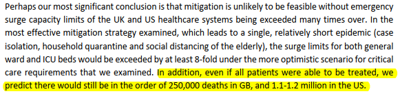

However, this modelling is, as to be expected, not universally agreed upon. In an [“Ask Me Anything” (AMA) on Reddit](https://www.reddit.com/r/Coronavirus/comments/fksnbf/im_bill_gates_cochair_of_the_bill_melinda_gates/) yesterday, Bill Gates expressed his views that this model used parameters that are “too negative.” You can see what he wrote in the figure below. Gates has some credibility in this arena by virtue of having spent the last few years sounding the alarm on the possible of an epidemic, most notable in a [TED talk](https://www.gatesnotes.com/Health/We-Are-Not-Ready-for-the-Next-Epidemic). In the talk, he calls the possibility of an epidemic “the greatest risk of global catastrophe”. Gates has also funded work in epidemiology, specifically in the form of the [Institute of Disease Modelling.](https://www.idmod.org/)

Figure 2: Gates AMA

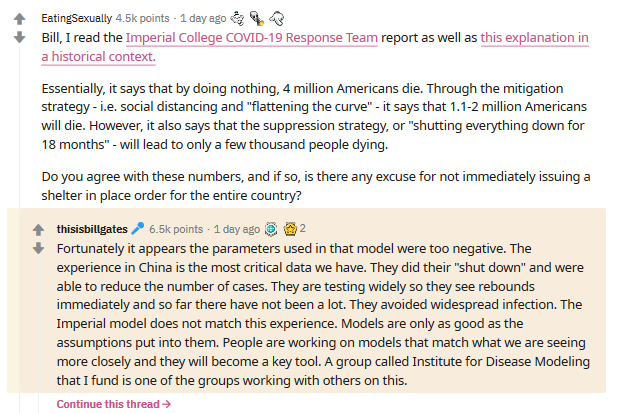

Despite his disagreement, Gates essentially still advocates the same strategy as the Imperial team - “social-distancing” - and so the difference between these two views, in terms of how terrible COVID-19 is likely to be, is for the most part irrelevant.

It’s worth noting that the team Gates funds (and referenced in his AMA) is the IDS, and they have not yet provided quantitative estimates on how severe COVID-19 could be (at least as far as I can tell from their portal).

Although a researcher from the Institute [is quoted](https://www.seattletimes.com/seattle-news/how-big-will-the-coronavirus-outbreak-get-this-bellevue-scientist-is-figuring-that-out/) as saying that he has been modeling exponential growth for years, but “it’s only in the last two weeks that I’ve felt it in my bones”

A [different take](https://www.statnews.com/2020/03/17/a-fiasco-in-the-making-as-the-coronavirus-pandemic-takes-hold-we-are-making-decisions-without-reliable-data/), from Stanford’s John P.A. Ioannidis, posits that perhaps extreme social-distancing is unwarranted. It does not, frustratingly, suggest any clear response. It does however suggest that the worst case scenario is 40 million global deaths globally whereas the worse case effects of a prolonged shutdown are “entirely unknown, and billions, not just millions, of lives may be eventually at stake.”

Reading somewhat between the lines, it seems that he suggests that shut-downs should be postponed at least until we have more data. Intriguingly (and controversially) he also claims that “If the level of the epidemic does overwhelm the health system and extreme measures have only modest effectiveness, then flattening the curve may make things worse”

Ioannidis’s pessimistic scenario is not one he espouses, but feels (to me) consistent with the Imperial model. Imperial’s is not a worse case scenario however, and so the two models are materially different.

While the Imperial model projects a million deaths for the US, which has a total population of 300 million people, it seems reasonable using Imperial’s parameters to expect 40 million people to die globally

So, which model is correct? Which model looks f(l)at in which parameter?

Of course there are many more models out there than those I’ve considered here, but it doesn’t matter for the point I want to make here: I don’t know which model is correct, and will likely never be able to tell. And unless you’re an epidemiologist, or someone working directly in modelling infectious disease, you’re probably can’t tell which is correct either.

You and I can’t even effectively evaluate the strengths and weaknesses of the model. Only the experts can.

# We’re all epidemiologists now

I saw a Twitter hash-tag that read “#armchairepidemiologist” and I thought it was fitting for the moment. The truth is, despite all the Googling around “epidemiology” that we’ve done, real expertise in modelling infectious disease is acquired over many years of intensive work. Our new-found familiarity with the concept of “R<sub>0</sub>” (R naught), gained from Twitter threads and podcasts, is in my view, unfortunately, not even nearly sufficient to allow us to comment authoritatively on any model.

Our skim reading of introductory epidemiology textbooks is no doubt really interesting, and does provide us with a better understanding of the general problem, but does not qualify us to make any reliable assessment of the models being used.

I’ve seen a similar scenario in the area of energy modelling - energy planning and modelling is a complex process requiring deep expertise. It’s also a topic which, in recent times, has also attracted a great deal of non-expert/public attention (for good reason!). A typical non-expert comment around solar and wind energy is that it’s intermittent - the sun does not shine at night, and the wind does not always blow. This is true and easily understood by a non-expert, but when modelling the entire system, these effects can be dramatically dampened, especially for example through a highly connected transmission grid. This “systems view” is less easily appreciated by non-experts.

The trouble with “we’re all epidemiologists/energy modellers now” is that this can create a damaging amount of noise. People, otherwise extremely competent in their field of expertise, can easily create confusion in the minds of others. Elon Musk’s comments around COVID-19 is a typical example

See [here](https://twitter.com/CT_Bergstrom/status/1241522140559503360) for example for a Twitter take down of a popular but seemingly incorrect take on COVID-19 by a non-expert

See [this piece](https://www.theverge.com/2020/3/20/21187760/twitter-elon-musk-tweet-coronavirus-misinformation) on Musk’s misinformation. He’s also commented on the Imperial report saying that there is a [“0% chance of anything close”](https://twitter.com/elonmusk/status/1240479781990199296)

All of this reminds me of that now infamous Brexit related statement: [“people in this country have had enough of experts.”](https://www.ft.com/content/3be49734-29cb-11e6-83e4-abc22d5d108c)

# What then?

If you can’t decide whose model is correct, despite watching eight hours of “intro to epidemiology”, how to decide which advise to take? In my view, take the majority expert view. In the case of COVID-19, that’s as much social-distancing as possible.

I have some thoughts around decision making under extreme uncertainty, particularly in highly time-sensitive situations, that will have to hold for another time. This post is all about the models baby!

# The public and expert models

If we, the non-expert public, cannot develop sufficient expertise to assess expert models, should we then be required to not interact with the expert models at all?

There’s no easy answer to that. My superficial scanning of the literature in the “participative democracy” field of scholarship indicates, to no-one’s surprise, that this is highly complex matter. And there are many other fields of research which consider the same question.

COVID-19 has provided some interesting insight on this, for me at least. Our new appreciation of this parameter called R<sub>0</sub>, and so many other parameters long studied in epidemiology, indicates to me that it’s impossible to prevent non-experts from attempting to engage expert-generated models. This is just human nature. When the government orders an economy wide shut-down, it’s just natural for many people to want to explore the reasons (i.e models) for this as thoroughly as they can. This theory is also supported by the wild popularity of the [Washington Post](https://www.washingtonpost.com/graphics/2020/world/corona-simulator/) piece on “flattening the curve” which included some beautiful simulations.

Similarly, when there are daily electricity black-outs, it’s instinctive for people to want to examine the “models” that lie at the heart of the debate around why they have to sit in the dark for four hours every day.

This really was a fantastic piece of journalism. See my simulations below

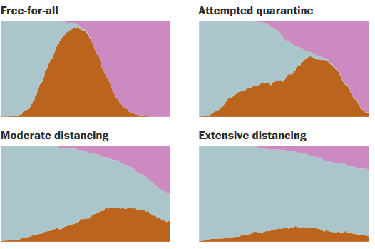

Figure 3: Washington Post Simulations

This instinct is especially true for non-experts who are familiar with modeling in other domains. People like myself (I’m familiar with energy planning modelling) are very easily tempted to [“look under the bonnet”](https://public.oed.com/blog/a-look-under-the-bonnet/) of models in other domains. All it takes is some impressive sounding terminology and the word “model.” Throw in any remotely fancy mathematical concept and you have a temptation too hard to resist. A number of my friends meet this definition, and I’ve observed many of them reading the Imperial paper and asking questions like I’ done.

Fancy mathematical notation is just *chef’s kiss*

Irrespective of whether non-experts can be persuaded from staying away from tinkering under the hood and creating harmful noise, there is another question of whether they should be? Again, COVID-19 has been instructive for me on this question.

Using now the American equivalent of the phrase

My training as an engineer has, I think, put me in a better place to understand exponential behaviour than many other professions (including it seems, and this is entirely anecdotal, doctors). This training has been invaluable in my understanding of how the Imperial paper gets to what seems like enormous numbers, and has ultimately lead to me being the champion of social-distancing in some of my immediate social circles. I’ve observed the same in friends from “quant” backgrounds too. And so, my exposure to the expert models, even as a non-expert, has, at least in the case of COVID-19, served to reinforce the message the experts are trying to communicate.

Which brings me to #scicomms, or “science communication.” This is a wonderful field of scholarship (of which I know very little) that studies, in part, the conveying of the outcomes and implications of modeling work done by experts, to the general public.

My experience in energy modeling has taught me that good SciComms is really difficult, but also really, really important. My observations of the COVID-19 models underscores this. Good SciComm, and no doubt this point is made more eloquently elsewhere by experts in this field (the irony!), is not simply about the communication of modeling work done. It spills over into how actual models are built, for example. Models built using “open” languages and on open platforms, can assist SciComm efforts simply by creating an atmosphere of trust.

Citation needed! But it makes sense?

Good SciComm needs, to my mind, to both encourage non-expert engagement with models, while simultaneously demonstrating the huge gap in expertise between experts and non-experts. If a COVID-19 model for example, can provide non-experts with the feeling of “ah so this is how it works” and at the same time “oh my God, that’s so complicated,” my hypothesis is that this would reduce unnecessary noise while creating support for the expert view.

SciComm is, in it’s own right, a fascinating complex socio-technical challenge.

# Modeling and SciComm of COVID-19 in South Africa

A really interesting example of SciComm done both well and badly with respect to COVID-19 has been that of the [Mail & Guardian newspaper](https://mg.co.za/) in South Africa.

As far as I can tell, the only people putting South African projections out into the public domain on the basis of *some* modelling is the Health Minister (who seems to be doing a job job under the circumstances) and the M&G. This is impressive on the part of the M&G - to be one of the few people apart from government making projections is commendable.

While I have been glued to my Twitter feed, I haven’t done an exhaustive search of modeling activity for COVID-19. No doubt, large corporate and consulting firms are running numbers on this

The other component done really well by the M&G is the comprehensiveness of its COVID-19 coverage. In this week’s edition, it has stories about halting evictions in the wake of COVID-19, to stories about artists affected by event cancellations. This breadth of coverage is impressive!

There are also some issues with the M&G SciComm effort. Firstly, they’ve built [their own model](https://mg.co.za/article/2020-03-19-projections-vital-to-deal-with-crisis/) /projection. Not being epidemiologists, this decision faces the “non-expert” problem I’ve talked about above. And it shows up immediately. The M&G model last week (16 March) [predicted 112,000 cases](https://mg.co.za/article/2020-03-16-the-mgs-latest-projection-on-covid-19-infections/) by April 1, but is this week projecting a more modest [4000 cases](https://mg.co.za/article/2020-03-19-projections-vital-to-deal-with-crisis/) by the same date. The first projection seems to have been built on basis of a 61% daily growth rate, a rate of spread that far exceeds anything being seemingly being used by epidemiologists anywhere.

The number of cases is actually a function of the number of tests done, so perhaps they thought testing capacity could be rapidly scaled up, uncovering already infected cases. A dubious assumption in itself)

This week, the M&G is also reporting model results it has seen from [SACEMA](http://www.sacema.org/). For some reason however, it leads (front page) with it’s own modeling results, which are more pessimistic. As pointed out in a [scathing Twitter thread](https://twitter.com/joshbudlender/status/1240896803945484289) by Josh Budlender, the 4000 cases it leads with exceeds the upper-bound of the SACEMA confidence interval.

Neither model is in the public domain, and perhaps this is something M&G should consider

Now, I full expect COVID-19 to spread really quickly, and think we may easily end up with 4000 cases in 10 days from now (if we can test fast and widely enough, which is something I haven’t a clue on). However, the large swings in M&G projections, the insistence on not leading with expert models, and the lack of addressing testing capacity in these model projections, undermines the credibility of the communication effort.

Despite all this, credit must be given to the M&G for attempting to model the growth and create an appropriate message around it. Specifically, it drives home the point about exponential growth, a concept about which the public is in desperate need of better educating. On balance, I think the M&G SciComm effort does more good than harm.

# More thoughts on the models!

This section is a collection of half-baked ideas around the epidemiology models I’ve talked about, and modeling in general, drawing on my experience in energy modelling. This is obviously a non-expert viewpoint, and should be taken with a pinch of salt.

## Openness

I’m curious about how the epidemiology field treats open models. In the energy modelling field, open models have become increasingly important and prevalent in the last few years. Initiatives like [openmod](http://openmod-initiative.org/) have helped the energy modeling world to transition to open models.

The [openmod manifesto](http://openmod-initiative.org/manifesto.html) talks about openness increasing “transparency and credibility.” It also reduces “wasteful double-work and improves overall quality.”

The Imperial paper, which seems to have been developed by the [MRC Centre for Global Infectious Disease Analysis](https://www.imperial.ac.uk/mrc-global-infectious-disease-analysis) based at Imperial College London, does not point to any particular software code which can be downloaded and executed. This might obviously be due to the time pressure under which the paper was produced (who knows how weird those comments in the model must read).

“God damn I wish Xi would send me the Wuhan baseline already!”

The paper does however state that the “basic structure of the model remains as previously published”. A very quick scan of Centre’s website, particularly the [lead author’s page](https://www.imperial.ac.uk/people/neil.ferguson) (Neil Ferguson) does not reveal any recent publications which include direct access to the actual software code used by the “Outbreak analysis and modelling” group at the Center. It’s very possible that I missed it though.

Page 4, under “Transmission Model”

Who has unfortunately tested positive for the disease as per [his tweet](https://mobile.twitter.com/neil_ferguson/status/1240696926183415811) and is now modelling a disease he is infected with. Hopefully he recovers soon

At first glance, it seems that epidemiological models, particularly those which model something like COVID-19 which has far reaching consequences, would benefit from an “open models” approach similar to that espoused by openmod. To a non-expert like myself, it does seem like it would promote transparency and all those other good things. It also seems to me that in situations of particular time-pressure, it would make sense to be releasing the underlying model together with results, such that other labs/ research groups can quickly validate and extend the models

For example, it might enable research groups globally to build fairly accurate models really quickly, particularly for countries without significant resources. An open model from the Imperial people *might* have enabled the M&G in South Africa to avoid the large swings in their predictions. Or maybe not. The point is moot.

This idea takes me back to the [Bill Gates Ted talk](https://www.gatesnotes.com/Health/We-Are-Not-Ready-for-the-Next-Epidemic) on the risk of an epidemic - he talks there about a multi-pronged approach, where he uses a war analogy (including proposing the idea of a “medical reserve corps”). I wonder now if one portion of this “war-effort infrastructure” required as part of the global response to an epidemic, is not an openly accessible and widely validate software model? Given how this is a very global problem, but resolving it relies on local (i.e. government) level action, could work on such an open model allow local government teams to very quickly generate reliable and useful results? If a lonely government researcher in a low-income country can successfully motivate for strong government action on the back of the message “the WHO and US are using the *same* model as we are,” the investment in such a model would be paid back many times over.

However, being a non-expert, I’m happy to recognize that there might be good reasons for not providing open access to the underlying model. For one, perhaps modelling of disease spread has fairly universally recognized underlying mechanics and therefore one need only provide the parameters used in the modelling exercise, and not the model itself. Perhaps this is why the [IDC](https://www.idmod.org/) have [only published a table of parameters](https://docs.google.com/document/d/1UZ4eyAqaNnmO4kYKF-Z9-HWA0y0wyR30RRAT-_Wxi9c/preview), and not any software code (as best as I can tell).

Secondly, perhaps there are dangers in publishing these models. Perhaps they could be used by non-experts to generate damaging noise, or perhaps even by other stakeholders for nefarious purposes. The current global panic certainly offers bad actors a lot of scope for their activities.

And there are probably other reasons too, that I haven’t thought about. However, my curiosity about the openness of epidemiological and energy models is a broader interest: I’m interested in how expert models can be better used to improve decision making in democratic settings. Expert models inform (to varying extents) many important decisions for society, and it’s important that we find ways to decrease the abuse of expert models in democratic decision making, while also improving their use. Openness is, to my mind, one of the key ways of achieving this.

## Modelling of socio-political behaviour

One the complexities I’ve been thinking about in energy modelling is the attempt to more closely incorporate human behaviour into well established energy models. Many system-wide energy models are linear optimisation problems, solving for the lowest total system cost. The models typically use as inputs the following: technology costs, technology characteristics, and the energy (specifically electricity) demand.. This gives you a good *theoretical* lowest system cost. These models are sometimes categorized as “techno-economic” (or “econometric”) in nature, and as the name suggests, they tend to overlook the “socio-political.”

A concept that would benefit enormously from better SciComm

This is heavily simplified, naturally

See [this paper](https://www.sciencedirect.com/science/article/abs/pii/0377221781902496?via%3Dihub) by Rath-Nagel and Voss(1981) on early energy models

A theoretical lowest costs is a neat outcome, but in practice, humans get in the way and make things messy. In South Africa for example, the Minister of Energy is actually now the Minister of Resources and Energy, and he has repeatedly delayed transitions to a cheaper (renewable) energy system. See [here](https://www.dailymaverick.co.za/article/2020-03-11-stage-4-load-shedding-hits-as-cabinet-divide-on-energy-deepens/), and [here](https://www.dailymaverick.co.za/article/2020-02-17-gwede-mantashes-dithering-exacerbates-the-energy-crisis/) for more. Based on these delays, I’ve often wondered if previous IPP rounds (the [REIPPP programme](https://www.gsb.uct.ac.za/files/EberhardNaude_REIPPPPReview_2017_1_1.pdf)) should have been made bigger (in both power and energy). This would have unfortunately limited the cost gains available via the energy learning curve, but would potentially have worked out cheaper over time given the power cuts that have occurred, driven in part by politically induced delays.

A self-inflicted wound!

I’m not sure if that was even possible, but it’s an interesting question

I’m referring here to more *robust* energy plans, falling in the class of “near-optimal” solutions. A deep topic for another day, but see [here](https://mobile.twitter.com/etrutnevyte/status/1181534567657857024) and [here](https://arxiv.org/abs/1910.01891) for more, for now.

My interest is around the modelling of this political delay - how can such a political event be incorporated in an energy model that is not built to naturally account for this? There are also other socio-political outcomes that have a significant impact on the “optimal solution.” For example, in South Africa, Eskom has been reported in the past to have been made to forego maintenance in order to keep the lights on, with political motives being the driver. This has had a long term impact on the health of the Eskom coal fleet, contributing substantially years later to the shortage in generation capacity.

[Here’s a quote](https://www.politicsweb.co.za/news-and-analysis/root-cause-of-demand-problem-goes-back-to-late-90s) from an Eskom manager some years back: “In the lead up to and during the 2010 World Cup, Eskom had a de facto obligation to meet national electricity demand embodied by the “Keep the Lights On” (KLO) requirement in Eskom’s Shareholder Compact and required Eskom to both defer maintenance and run the plant very hard when it was available,” Ross-Jones said. [Here](https://m.engineeringnews.co.za/article/how-power-utility-eskom-is-hobbling-south-africas-economy-2018-12-05/rep_id:4433) and [here](https://mg.co.za/article/2017-11-07-former-eskom-ceo-breaks-down-culture-of-maintenance-deferral/)(from a former CEO) are corroborating reports

This type of political decision leads to substantial deterioration in plant performance, particularly in the later years of a plant’s life-span. Given that this has a very real impact on the energy system, this should be incorporated in the models (most easily in the form of adjusting the plant’s “technology characteristics”).

All of the above is to substantiate my view that, at least in the case of energy modelling, there ought to be a much deeper incorporation of political science and sociology in traditional techno-economic models.

Yup, I know that economics is a social science. A post for another day

I think the same *might* be true for epidemiological modelling. It certainly seems like a category of analysis that is extremely sensitive to social and political developments. I could be comprehensively incorrect about this, being a non-expert, but if energy modelling suffers from this challenge, then there is at least a non-zero probability that many other modelling activities do too.

And therefore not yet pre-reviewed

How do epidemiological models handle political events that so dramatically impact one of its key parameters over a short period of time? Is there sufficient temporal resolution in these models to project outcomes that would match Wuhan’s dramatic trajectory? Such a rapid change in R<sub>0</sub> depends, as far as I can tell, on a government’s ability to limit the interaction between people. Political scientists seem better placed to provide insight on this than most others, and as a result should be key contributors to epidemiological model building.

I don’t understand the models even remotely well enough to be able to tell if they account well for socio-political events like a rapidly changing R<sub>0</sub>. For instance, the table below from the Imperial model does not seem to clarify if the R<sub>0</sub> given here are simply initial condition R<sub>0</sub>, or if there is another mechanism that determines that spread while R<sub>0</sub> remains constant. The extract below only shows a small portion of the results in the paper.

One mechanism I can think of is if R<sub>0</sub> represents the number of people that a contagious person will infect out of every X people they interact with. This makes sense to my non-expert brain, because then R<sub>0</sub> represents how contagious a disease is inherently (“biologically”), while the number of infections is determined as a function of the number of interactions *and* R<sub>0</sub>

Figure 4: Imperial Model: Results Table

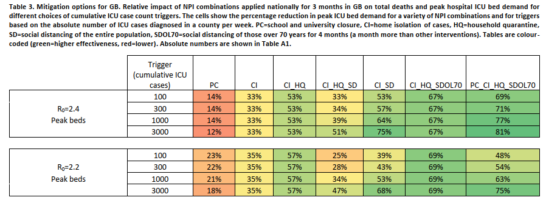

The [USA has also reacted poorly](https://time.com/5805683/trump-administration-coronavirus/), at least initially, to the outbreak. Further, it’s unlikely in my view that they are able to respond after the fact as strongly as China was. But that’s only my view, and my larger point here is that political scientists and sociologists are much better placed to assess whether the USA has the political willpower and sociological make-up to implement the same degree of social-distancing that China achieved.

Some people have pointed to China and Singapore’s success in implementing social-distancing to support the idea that this is easier in non-democracies. However, South Korea has had good success too, and that’s a democracy.

[Here’s](https://mobile.twitter.com/ElephantEating/status/1238037687300390912) a pretty succinct tweet that expresses this sentiment perfectly, I think

[figure not shown]

Figure 5: South Korea, a democracy, and COVID-19

The really interesting thing about the South Korea COVID-19 case, to me at least, is that they used tracking tools that can easily be considered really invasive (and similar I think to those [employed in Singapore](https://mobile.twitter.com/RyutaroUchiyama/status/1234616723615166465)), but this happened within a democratic context. See sidenote here for more critical readings of South Korea’s response. This is fascinating sociological phenomenon, whether positive or negative, but I’m not sure that this degree of tracking would be possible/acceptable in all cultures. The people best placed to evaluate the tendency for a country and it’s sub-cultures to accept intrusive tracking for virus control are probably sociologists, and therefore,like political scientists, these are experts that should be part of any *core* team building epidemiological models.

[The Guardian](https://www.theguardian.com/world/2020/mar/06/more-scary-than-coronavirus-south-koreas-health-alerts-expose-private-lives) on the danger of S.Korea’s response, and MIT’s [Technology Review](https://www.technologyreview.com/s/615329/coronavirus-south-korea-smartphone-app-quarantine/) on the smartphone app that powers this

I’m making the case here, I think, for modelling that is traditionally very technical (energy modeling and perhaps epidemiology) and typically build by math types, to embrace their social science colleagues.

I’m certainly not the first to do this in the energy space

## Socially-orientated APIs

I think a step towards this might be to introduce the concept of “socially-orientated APIs” for these models. I’m using the phrase [“API”](https://en.wikipedia.org/wiki/Application_programming_interface) here, mostly because it sounds cool, but really what I’m proposing is a better *interface* between the existing techno-economic models, and the socio-political models. An interface to bridge the gap between the efforts of the engineer/math/physics/biology/chemistry people, and the psychology/sociology/politics/anthropology people.

Application programming interface, which, according to Wikipedia, “allows third parties to extend its functionality beyond that which existed out of the box”

An interface that provides a mechanism for these two groups to *jointly* model.

For example, in the case of energy modelling, it would be really useful to have a document that maps the key type of political events to the variables/ parameters in the techno-economic optimisation model. As an example here, a key type of political event is “ignoring maintenance”, which maps to a reduced “power plant capacity factor” in the techno-economic model. In the sociological realm, the motivation individual people have to become “energy independent” is a social phenomenon that maps to the “new roof-top PV generation” available in each time period in the a typical energy optimisation model (techno-economic).

In a similar manner, an interface in epidemiological modelling that maps R<sub>0</sub> to different political events would be useful to bridge the gap (again, perhaps this gaps is less pronounced in epidemiology than I think).

Perhaps different types of political administration: say Republican or Democrat in the US

In Japan where, handshakes are a rarer cultural expression than in European cultures (and which has been [credited in part](https://www.bloomberg.com/news/articles/2020-03-19/a-coronavirus-explosion-was-expected-in-japan-where-is-it) with containing the COVID-19 spread there, sociologists who study this behavior would be able to better shape the “doubling time” parameter^ that seems to be fundamental to epidemiological modelling. I’m suggesting here that mapping cultural habits with technical parameters provides a stronger mechanism to bring the work of social scientists into the mathematical modelling that heavily drives decision making.

See also Twitter thread [here](https://twitter.com/ShaneJ614/status/1240793264661258241)

I recognize that the immediate and perhaps most glaring problem with my proposal is its heavy quant bent. Asking an anthropologists to provide a number that “quantifies how often Japanese shake hands” is tantamount to blasphemy.But the focus on this approach is *not* quantification, and more “direction of effect”: instead of focusing on numbers, the focus should be to have a conversation with the anthropologists who can say that doubling time/other parameter should be higher for Italy than for Japan, because Italians kiss each on the cheek all the time and the Japanese don’t ([ceteris paribus](https://en.wikipedia.org/wiki/Ceteris_paribus)).

Everything else being equal

Of course, there’s a lot more to than this “black-box API” approach that’s required to truly bridge the gap in modelling, but I submit that this is a good initial start.

Ultimately, the answer to “does my model look f(l)at in this parameter?” depends on the model and the parameter, which in turn depends on both the maths people *and* the humanities people.

Word Count: ~4800 words

# Archive of Links

Because links on the internet break, I’ve captured as many of the pieces referenced and link to in this post on the “Way Back Machine”, hosted at [archive.org](https://archive.org/).

Each URL used above is pasted below, and is followed by an archive link. So if any link breaks, search for it on this page (e.g. “https://archive.org/” ) and find the corresponding archive link. Please note that sometimes webpages don’t archive properly, and some are not archivable at all. ¯_(ツ)_/¯

**Click here to unfold archive links**

- (https://www.washingtonpost.com/history/2020/03/12/during-pandemic-isaac-newton-had-work-home-too-he-used-time-wisely/) | [archive link](https://web.archive.org/web/20200322175716/https://www.washingtonpost.com/history/2020/03/12/during-pandemic-isaac-newton-had-work-home-too-he-used-time-wisely/)
- (https://www.imperial.ac.uk/media/imperial-college/medicine/sph/ide/gida-fellowships/Imperial-College-COVID19-NPI-modelling-16-03-2020.pdf) | [archive link](https://web.archive.org/web/20200322175724/https://www.imperial.ac.uk/media/imperial-college/medicine/sph/ide/gida-fellowships/Imperial-College-COVID19-NPI-modelling-16-03-2020.pdf)
- (https://mobile.twitter.com/jburnmurdoch/status/1240629424871047168) | [archive link](https://web.archive.org/web/20200322182650/https://mobile.twitter.com/jburnmurdoch/status/1240629424871047168)
- (https://mobile.twitter.com/ASlavitt/status/1240348436471246850) | [archive link](https://web.archive.org/web/20200322175750/https://mobile.twitter.com/ASlavitt/status/1240348436471246850)
- (https://twitter.com/jeremycyoung/status/1239975682643357696) | [archive link](https://web.archive.org/web/20200322183148/https://twitter.com/jeremycyoung/status/1239975682643357696)
- (https://www.reddit.com/r/Coronavirus/comments/fksnbf/im_bill_gates_cochair_of_the_bill_melinda_gates/) | [archive link](https://web.archive.org/web/20200322175808/https://www.reddit.com/r/Coronavirus/comments/fksnbf/im_bill_gates_cochair_of_the_bill_melinda_gates/)
- (https://www.statnews.com/2020/03/17/a-fiasco-in-the-making-as-the-coronavirus-pandemic-takes-hold-we-are-making-decisions-without-reliable-data/) | [archive link](https://web.archive.org/web/20200322175848/https://www.statnews.com/2020/03/17/a-fiasco-in-the-making-as-the-coronavirus-pandemic-takes-hold-we-are-making-decisions-without-reliable-data/)
- (https://twitter.com/CT_Bergstrom/status/1241522140559503360) | [archive link](https://web.archive.org/web/20200322183158/https://twitter.com/CT_Bergstrom/status/1241522140559503360)
- (https://web.archive.org/web/20200322183158/https://twitter.com/CT_Bergstrom/status/1241522140559503360) | [archive link](https://web.archive.org/web/20200319212438/https://www.theverge.com/environment)
- (https://twitter.com/elonmusk/status/1240479781990199296) | [archive link](https://web.archive.org/web/20200322183221/https://twitter.com/elonmusk/status/1240479781990199296)
- (https://www.ft.com/content/3be49734-29cb-11e6-83e4-abc22d5d108c) | [archive link](https://web.archive.org/web/20200322183236/https://www.ft.com/content/3be49734-29cb-11e6-83e4-abc22d5d108c)
- (https://www.washingtonpost.com/graphics/2020/world/corona-simulator/) | [archive link](https://web.archive.org/web/20200322183238/https://www.washingtonpost.com/graphics/2020/world/corona-simulator/)
- (https://public.oed.com/blog/a-look-under-the-bonnet/) | [archive link](https://web.archive.org/web/20200322183246/https://public.oed.com/blog/a-look-under-the-bonnet/)
- (https://mg.co.za/article/2020-03-19-projections-vital-to-deal-with-crisis/) | [archive link](https://web.archive.org/web/20200322183936/https://mg.co.za/article/2020-03-19-projections-vital-to-deal-with-crisis/)
- (https://mg.co.za/article/2020-03-19-projections-vital-to-deal-with-crisis/) | [archive link](https://web.archive.org/web/20200322184001/https://mg.co.za/article/2020-03-19-projections-vital-to-deal-with-crisis/)
- (https://mg.co.za/article/2020-03-16-the-mgs-latest-projection-on-covid-19-infections/) | [archive link](https://web.archive.org/web/20200322184013/https://mg.co.za/article/2020-03-16-the-mgs-latest-projection-on-covid-19-infections/)
- (http://www.sacema.org/) | [archive link](https://web.archive.org/web/20200322184023/http://www.sacema.org/)
- (https://twitter.com/joshbudlender/status/1240896803945484289) | [archive link](https://web.archive.org/web/20200322184035/https://twitter.com/joshbudlender/status/1240896803945484289)
- (https://www.imperial.ac.uk/mrc-global-infectious-disease-analysis) | [archive link](https://web.archive.org/web/20200322184413/https://www.imperial.ac.uk/mrc-global-infectious-disease-analysis)
- (https://www.imperial.ac.uk/people/neil.ferguson) | [archive link](https://web.archive.org/web/20200322184430/https://www.imperial.ac.uk/people/neil.ferguson)
- (https://www.gatesnotes.com/Health/We-Are-Not-Ready-for-the-Next-Epidemic) | [archive link](https://web.archive.org/web/20200322185102/https://www.gatesnotes.com/Health/We-Are-Not-Ready-for-the-Next-Epidemic)
- (https://docs.google.com/document/d/1UZ4eyAqaNnmO4kYKF-Z9-HWA0y0wyR30RRAT-_Wxi9c/preview) | [archive link](https://web.archive.org/web/20200322185112/https://docs.google.com/document/d/1UZ4eyAqaNnmO4kYKF-Z9-HWA0y0wyR30RRAT-_Wxi9c/preview)
- (https://www.sciencedirect.com/science/article/abs/pii/0377221781902496?via%3Dihub) | [archive link](https://web.archive.org/web/20200322185131/https://www.sciencedirect.com/science/article/abs/pii/0377221781902496?via%3Dihub)
- (https://www.gsb.uct.ac.za/files/EberhardNaude_REIPPPPReview_2017_1_1.pdf) | [archive link](https://web.archive.org/web/20200322185159/https://www.gsb.uct.ac.za/files/EberhardNaude_REIPPPPReview_2017_1_1.pdf)
- (https://mobile.twitter.com/etrutnevyte/status/1181534567657857024) | [archive link](https://web.archive.org/web/20200322185211/https://mobile.twitter.com/etrutnevyte/status/1181534567657857024)
- (https://arxiv.org/abs/1910.01891) | [archive link](https://web.archive.org/web/20200322185212/https://arxiv.org/abs/1910.01891)
- (https://www.politicsweb.co.za/news-and-analysis/root-cause-of-demand-problem-goes-back-to-late-90s) | [archive link](https://web.archive.org/web/20200322185235/https://www.politicsweb.co.za/news-and-analysis/root-cause-of-demand-problem-goes-back-to-late-90s)
- (https://www.nytimes.com/2020/01/29/opinion/coronavirus-china-government.html) | [archive link](https://web.archive.org/web/20200322185445/https://www.nytimes.com/2020/01/29/opinion/coronavirus-china-government.html)
- (https://www.medrxiv.org/content/10.1101/2020.02.12.20022434v2) | [archive link](https://web.archive.org/web/20200322185515/https://www.medrxiv.org/content/10.1101/2020.02.12.20022434v2)
- (https://time.com/5805683/trump-administration-coronavirus/) | [archive link](https://web.archive.org/web/20200322185525/https://time.com/5805683/trump-administration-coronavirus/)
- (https://mobile.twitter.com/ElephantEating/status/1238037687300390912) | [archive link](https://web.archive.org/web/20200322185607/https://mobile.twitter.com/ElephantEating/status/1238037687300390912)
- (https://mobile.twitter.com/RyutaroUchiyama/status/1234616723615166465) | [archive link](https://web.archive.org/web/20200322185619/https://mobile.twitter.com/RyutaroUchiyama/status/1234616723615166465)
- (https://www.theguardian.com/world/2020/mar/06/more-scary-than-coronavirus-south-koreas-health-alerts-expose-private-lives) | [archive link](https://web.archive.org/web/20200322185630/https://www.theguardian.com/world/2020/mar/06/more-scary-than-coronavirus-south-koreas-health-alerts-expose-private-lives)
- (https://en.wikipedia.org/wiki/Application_programming_interface) | [archive link](https://web.archive.org/web/20200322185647/https://en.wikipedia.org/wiki/Application_programming_interface)
- (https://twitter.com/ShaneJ614/status/1240793264661258241) | [archive link](https://web.archive.org/web/20200322185705/https://twitter.com/ShaneJ614/status/1240793264661258241)
- (https://en.wikipedia.org/wiki/Ceteris_paribus) | [archive link](https://web.archive.org/web/20200322185721/https://en.wikipedia.org/wiki/Ceteris_paribus)
- (blank) | archive link

# References

RyutaroUchiyamaon Twitter: “I’m Stunned by the Depth of #coronavirus Information Being Released in #Singapore. On This Website You Can See Every Known Infection Case, Where the Person Lives and Works, Which Hospital They Got Admitted to, and the Network Topology of Carriers, All Laid out on a Time-Series Https://T.Co/WckG8KpPDE” / Twitter’. n.d. Twitter. Accessed 22 March 2020. https://mobile.twitter.com/ryutarouchiyama/status/1234616723615166465.

‘A Look under the Bonnet in the October 2018 Update’. 2018. Oxford English Dictionary. 3 October 2018. https://public.oed.com/blog/a-look-under-the-bonnet/.

‘Andy Slavitt @ 🏡 on Twitter: “A Lot of the Talk Today Is about the Imperial College Paper That Came out March 16 with Some Very Dire Analysis. This Deserves Some Explanation. But Know I’m a Layman &amp; so This Comes from Scientists I’ve Talked to. 2/ Https://T.Co/SRZSQTX49y” / Twitter’. n.d. Twitter. Accessed 22 March 2020. https://mobile.twitter.com/aslavitt/status/1240348436471246850.

‘Application Programming Interface’. 2020. In *Wikipedia*. https://en.wikipedia.org/w/index.php?title=Application_programming_interface&oldid=946632695.

‘Britain Has Had Enough of Experts, Says Gove | Financial Times’. n.d. Accessed 22 March 2020. https://www.ft.com/content/3be49734-29cb-11e6-83e4-abc22d5d108c.

‘Carl T. Bergstrom on Twitter: “1. I Hate to Invest Precious Time on Taking Apart the Atrocious @aginnt Article Pictured below, but It Is Getting Too Much Traction Here and Even in Traditional Media. This Thread Could Be Far Longer than It Is, but I’m Doing My Best to Only Discuss the Most Glaring Flaws. Https://T.Co/EFA7ATQRbX” / Twitter’. n.d. Twitter. Accessed 22 March 2020. https://twitter.com/ct_bergstrom/status/1241522140559503360.

‘*Ceteris Paribus*’. 2020. In *Wikipedia*. https://en.wikipedia.org/w/index.php?title=Ceteris_paribus&oldid=943804104.

‘EberhardNaude_REIPPPPReview_2017_1_1.Pdf’. n.d. Accessed 22 March 2020. https://www.gsb.uct.ac.za/files/EberhardNaude_REIPPPPReview_2017_1_1.pdf.

‘Elon Musk on Twitter: “@cleantechnica 0% Chance of Anything Close” / Twitter’. n.d. Twitter. Accessed 22 March 2020. https://twitter.com/elonmusk/status/1240479781990199296.

‘Epidemiological Parameters Table’. n.d. Google Docs. Accessed 22 March 2020. https://docs.google.com/document/d/1UZ4eyAqaNnmO4kYKF-Z9-HWA0y0wyR30RRAT-_Wxi9c/preview?usp=embed_facebook.

‘Eric Hittinger on Twitter: “South Korea Korea Trying, Very Patiently, to Explain How a Democracy Controls the Coronavirus. Is Anyone Listening? Https://T.Co/MuhVpCqll8” / Twitter’. n.d. Twitter. Accessed 22 March 2020. https://mobile.twitter.com/elephanteating/status/1238037687300390912.

‘Evelina Trutnevyte on Twitter: “Wonderful That @nworbmot and Colleagues Start Looking into near-Optimal Solutions in #renewable #energy #models. The near-Optimal Community Is Growing! @jfdecarolis @sasse_jan Https://T.Co/YAG7ipXSES” / Twitter’. n.d. Twitter. Accessed 22 March 2020. https://mobile.twitter.com/etrutnevyte/status/1181534567657857024.

Ferguson, Neil M, Daniel Laydon, Gemma Nedjati-Gilani, Natsuko Imai, Kylie Ainslie, Marc Baguelin, Sangeeta Bhatia, et al. 2020. ‘Impact of Non-Pharmaceutical Interventions (NPIs) to Reduce COVID- 19 Mortality and Healthcare Demand’, 20.

Gates, Bill. n.d. ‘We’re Not Ready for the Next Epidemic’. Gatesnotes.Com. Accessed 22 March 2020. https://www.gatesnotes.com/Health/We-Are-Not-Ready-for-the-Next-Epidemic.

‘Home - Professor Neil Ferguson’. n.d. Accessed 22 March 2020. https://www.imperial.ac.uk/people/neil.ferguson.

‘In the Coronavirus Pandemic, We’re Making Decisions without Reliable Data’. 2020. *STAT* (blog). 17 March 2020. https://www.statnews.com/2020/03/17/a-fiasco-in-the-making-as-the-coronavirus-pandemic-takes-hold-we-are-making-decisions-without-reliable-data/.

‘Institute for Disease Modeling’. n.d. Accessed 22 March 2020a. https://www.idmod.org/.

‘Institute for Disease Modeling’. ———. n.d. Accessed 22 March 2020b. https://www.idmod.org/.

‘Jeremy C. Young on Twitter: “We Can Now Read the Imperial College Report on COVID-19 That Led to the Extreme Measures We’ve Seen in the US This Week. Read It; It’s Terrifying. I’ll Offer a Summary in This Thread; Please Correct Me If I’ve Gotten It Wrong. Https://T.Co/AwE2cHIbeJ” / Twitter’. n.d. Twitter. Accessed 22 March 2020. https://twitter.com/jeremycyoung/status/1239975682643357696.

‘John Burn-Murdoch on Twitter: “NEW: We Dug through the Imperial College Report to Distill the Core Findings from the Analysis of How Coronavirus Might Spread in the UK and US under Different Scenarios Https://T.Co/YbikX9h4Np Https://T.Co/WzERm0ki3v” / Twitter’. n.d. Twitter. Accessed 22 March 2020. https://mobile.twitter.com/jburnmurdoch/status/1240629424871047168.

‘Josh Budlender on Twitter: “Wow. @mailandguardian Double down on Irresponsible Self-Made COVID-19 Projections. Honestly Don’t Know How They Think This Is in Public Interest. Not Understanding How Complex a Field like Epidemiology Is? Hubris? Maybe Just Click-Hunting? Problems-&gt; (1/9) Https://T.Co/LBVT10R7yL” / Twitter’. n.d. Twitter. Accessed 22 March 2020. https://twitter.com/joshbudlender/status/1240896803945484289.

Kim, Max S. n.d. ‘South Korea Is Watching Quarantined Citizens with a Smartphone App’. MIT Technology Review. Accessed 22 March 2020. https://www.technologyreview.com/s/615329/coronavirus-south-korea-smartphone-app-quarantine/.

Kim, Nemo. 2020. ‘“More Scary than Coronavirus”: South Korea’s Health Alerts Expose Private Lives’. *The Guardian*, 6 March 2020, sec. World news. https://www.theguardian.com/world/2020/mar/06/more-scary-than-coronavirus-south-koreas-health-alerts-expose-private-lives.

Kristof, Nicholas. 2020. ‘Opinion | Coronavirus Spreads, and the World Pays for China’s Dictatorship’. *The New York Times*, 29 January 2020, sec. Opinion. https://www.nytimes.com/2020/01/29/opinion/coronavirus-china-government.html.

‘Mail & Guardian - Africa’s Best Read’. n.d. The Mail & Guardian. Accessed 22 March 2020. https://mg.co.za/.

‘M&G’s Latest Covid-19 Projections’. 2020. *The Mail & Guardian* (blog). 19 March 2020. https://mg.co.za/article/2020-03-19-projections-vital-to-deal-with-crisis/.

Mizumoto, Kenji, Katsushi Kagaya, and Gerardo Chowell. 2020. ‘Early Epidemiological Assessment of the Transmission Potential and Virulence of Coronavirus Disease 2019 (COVID-19) in Wuhan City: China, January-February, 2020’. *MedRxiv*, March, 2020.02.12.20022434. https://doi.org/10.1101/2020.02.12.20022434.

‘MRC Centre for Global Infectious Disease Analysis’. n.d. Imperial College London. Accessed 22 March 2020. http://www.imperial.ac.uk/medicine/departments/school-public-health/infectious-disease-epidemiology/mrc-global-infectious-disease-analysis/.

‘Neil_ferguson on Twitter: “Again, Many Many Thanks for Everyone’s Very Kind Support. I Was Tested given My Recent Proximity to People Leading the UK Response. Positive. Which Is a Strange Experience - to Be Infected by the Virus One Is Modelling 🙄. Still Feeling Rough, but Not Awful.” / Twitter’. n.d. Twitter. Accessed 22 March 2020. https://mobile.twitter.com/neil_ferguson/status/1240696926183415811.

Neumann, Fabian, and Tom Brown. 2019. ‘The Near-Optimal Feasible Space of a Renewable Power System Model’. *ArXiv:1910.01891 [Physics]*, October. http://arxiv.org/abs/1910.01891.

‘Nodes » SACEMA’. n.d. Accessed 22 March 2020. http://www.sacema.org/.

O’Kane, Sean. 2020. ‘Twitter Won’t Remove Irresponsible Elon Musk Tweet about Coronavirus’. The Verge. 20 March 2020. https://www.theverge.com/2020/3/20/21187760/twitter-elon-musk-tweet-coronavirus-misinformation.

‘Openmod - Open Energy Modelling Initiative’. n.d. Accessed 22 March 2020a. http://openmod-initiative.org/.

‘Openmod - Open Energy Modelling Initiative’. ———. n.d. Accessed 22 March 2020b. http://openmod-initiative.org/manifesto.html.

Rath-Nagel, St., and A. Voss. 1981. ‘Energy Models for Planning and Policy Assessment’. *European Journal of Operational Research* 8 (2): 99–114. https://doi.org/10.1016/0377-2217(81)90249-6.

‘R/Coronavirus - I’m Bill Gates, Co-Chair of the Bill & Melinda Gates Foundation. AMA about COVID-19.’ n.d. Reddit. Accessed 22 March 2020. https://www.reddit.com/r/Coronavirus/comments/fksnbf/im_bill_gates_cochair_of_the_bill_melinda_gates/.

RetropolisEmailEmailBioBioFollowFollow, Gillian Brockell closeGillian BrockellStaff writer for. n.d. ‘During a Pandemic, Isaac Newton Had to Work from Home, Too. He Used the Time Wisely.’ Washington Post. Accessed 22 March 2020. https://www.washingtonpost.com/history/2020/03/12/during-pandemic-isaac-newton-had-work-home-too-he-used-time-wisely/.

‘Root Cause of Demand Problem Goes Back to Late 1990s - Eskom - NEWS & ANALYSIS | Politicsweb’. n.d. Accessed 22 March 2020. https://www.politicsweb.co.za/news-and-analysis/root-cause-of-demand-problem-goes-back-to-late-90s.

‘Shane on Twitter: “15/ Build-in Social Distancing. While Handshaking Occurs to Some Extent Mainly in Business Settings, Non-Contact Bowing Remains Primary Form of Greeting.” / Twitter’. n.d. Twitter. Accessed 22 March 2020. https://twitter.com/shanej614/status/1240793264661258241.

‘The M&G’s Projection on Covid-19 Infections on Monday 16 March’. 2020. *The Mail & Guardian* (blog). 16 March 2020. https://mg.co.za/article/2020-03-16-the-mgs-latest-projection-on-covid-19-infections/.

‘The Trump Administration Fumbled Its Initial Response to Coronavirus. Is There Enough Time to Fix It?’ n.d. Time. Accessed 22 March 2020. https://time.com/5805683/trump-administration-coronavirus/.

‘These Simulations Show How to Flatten the Coronavirus Growth Curve’. n.d. Washington Post. Accessed 22 March 2020. https://www.washingtonpost.com/graphics/2020/world/corona-simulator/.